# **NLP Project - Article Categorization**

[figure not shown]

**Description**

**Business Context** In the dynamic landscape of the media and news industry, the ability to swiftly categorize and curate content has become a strategic imperative. The vast volume of information demands efficient systems to organize and present content to the audience. The media industry, being the pulse of information dissemination, grapples with the continuous influx of articles spanning diverse topics. Ensuring that the right articles reach the right audience promptly is not just a logistical necessity but a critical component in retaining and engaging audiences in an age of information overload.

Common Industry Challenges: Amidst the ceaseless flow of news, media organizations encounter challenges such as:

Information Overload: The sheer volume of articles makes manual categorization impractical. Timeliness: Delays in categorizing articles can result in outdated or misplaced content. User Engagement: Providing personalized and relevant content is vital for sustaining user interest.

**Problem Definition**

InfoWorld, a prominent player in the media landscape, faces these challenges on a monumental scale. With a vast repository of articles covering World affairs, Sports, Business, and Sci/Tech, the need for an advanced and automated system to categorize articles has become increasingly evident. The manual efforts required for categorizing such a diverse range of articles are substantial, often leading to delays and potential inaccuracies. To streamline and optimize this process, the organization recognizes the imperative of adopting cutting-edge technologies, particularly machine learning, to automate and enhance the categorization of content.

As a data scientist on InfoWorld's data team, the task is to analyze articles and construct a predictive model for categorizing them. The goal is to optimize the categorization process, ensuring timely and personalized delivery. Leveraging advanced machine learning techniques and prompt engineering, the initiative aims to address technical challenges and pave the way for a seamless intersection of technology and media.

**Data Dictionary**

Article: The main body of the article or content containing detailed information and context.

Category: Categorization indicating the broad topic or subject of the content.

**Data Overview**

- Load the dataset - Print the overview of the data (first few rows, shape, etc)

```python
# Importing necessary libraries
import pandas as pd
from google.colab import drive

# Mounting Google Drive to access files
print("Mounting Google Drive...")
drive.mount('/content/drive')

# Defining the path to the dataset
file_path = '/content/drive/MyDrive/Colab_Notebooks/NLP_Project/Article_Categorization/article_data.csv'

# Loading the dataset into a DataFrame
print("Loading the dataset into a pandas DataFrame...")
data = pd.read_csv(file_path)
```

```
Mounting Google Drive...
Loading the dataset into a pandas DataFrame...
```

```python
# Displaying the first few rows of the dataset
print("Displaying the first 5 rows of the dataset:")
print(data.head())
```

```
Displaying the first 5 rows of the dataset:
                                             Article  Category
0  Sudan Govt rejects call to separate religion, ...         0
1  Hassan:  #39;Abhorrent act #39; says Blair Wes...         0
2  Sharon Says Gaza Evacuation Set for 2005 (AP) ...         0
3  Prince Charles chastised for  quot;old fashion...         0
4  U.S. Says N.Korea Blast Probably Not Nuclear  ...         0
```

```python
# Displaying the shape (number of rows and columns) of the dataset
print("Displaying the shape of the dataset (rows, columns):")
print(data.shape)
```

```
Displaying the shape of the dataset (rows, columns):
(4000, 2)
```

```python
# Displaying basic information including data types and missing values
print("Displaying dataset information (data types, non-null counts):")
print(data.info())
```

```
Displaying dataset information (data types, non-null counts):
<class 'pandas.core.frame.DataFrame'>
RangeIndex: 4000 entries, 0 to 3999
Data columns (total 2 columns):
 #   Column    Non-Null Count  Dtype
---  ------    --------------  -----
 0   Article   4000 non-null   object
 1   Category  4000 non-null   int64
dtypes: int64(1), object(1)
memory usage: 62.6+ KB
None
```

```python
# Displaying category distribution
print("Checking the distribution of articles by category:")
print(data['Category'].value_counts())
```

```
Checking the distribution of articles by category:
Category
0    1000
1    1000
2    1000
3    1000
Name: count, dtype: int64
```

```python
# Importing necessary libraries for visualization
import matplotlib.pyplot as plt
import seaborn as sns

# Setting plot aesthetics for better readability
sns.set(style="whitegrid")

# Step 1: Checking for missing values in each column
print("Checking for missing values in the dataset:")
print(data.isnull().sum())
```

```
Checking for missing values in the dataset:
Article     0
Category    0
dtype: int64
```

```
Visualizing the distribution of articles by category:
```

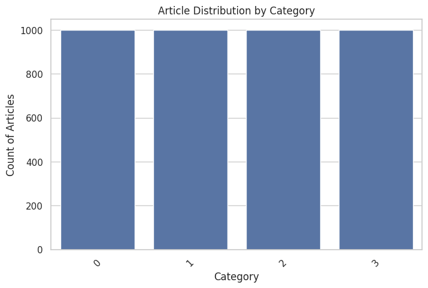

```python
# Step 2: Visualizing the distribution of articles by category
print("Visualizing the distribution of articles by category:")
plt.figure(figsize=(8,5))
sns.countplot(x='Category', data=data, order=data['Category'].value_counts().index)
plt.title("Article Distribution by Category")
plt.xlabel("Category")
plt.ylabel("Count of Articles")
plt.xticks(rotation=45)
plt.show()
```

```
Creating a new column for article length and visualizing its distribution:
```

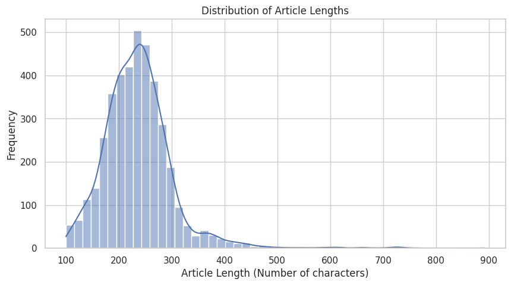

```python
# Step 3: Analyzing article length to identify any outliers or patterns
print("Creating a new column for article length and visualizing its distribution:")
data['Article_Length'] = data['Article'].apply(len)

plt.figure(figsize=(10,5))
sns.histplot(data['Article_Length'], bins=50, kde=True)
plt.title("Distribution of Article Lengths")
plt.xlabel("Article Length (Number of characters)")
plt.ylabel("Frequency")
plt.show()
```

```
Visualizing article length across different categories:
```

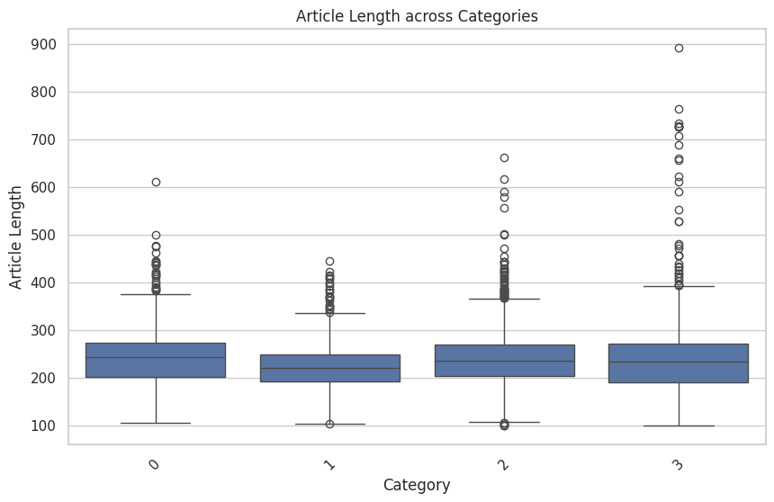

```python
# Step 4: Comparing article length across different categories
print("Visualizing article length across different categories:")
plt.figure(figsize=(10,6))
sns.boxplot(x='Category', y='Article_Length', data=data)
plt.title("Article Length across Categories")
plt.xlabel("Category")
plt.ylabel("Article Length")
plt.xticks(rotation=45)
plt.show()
```

===================================================================================================

**Model Building - Sentence Transformer + ML**

- Define the sentence transformer model and use it to encode the data - Train-test Split - Random Forest - Base model - Base model with class_weights - Hyperparameter tuning - Check the performance of the models

```python
# Importing necessary libraries
import pandas as pd
from sklearn.model_selection import train_test_split, GridSearchCV
from sklearn.ensemble import RandomForestClassifier
from sklearn.metrics import classification_report, confusion_matrix, accuracy_score
from sentence_transformers import SentenceTransformer
import numpy as np

# Step 1: Defining Sentence Transformer model (all-MiniLM-L6-v2)
print("Initializing the Sentence Transformer model for encoding text...")
model = SentenceTransformer('all-MiniLM-L6-v2')
```

```
Initializing the Sentence Transformer model for encoding text...
```

```python
# Step 2: Encoding articles using the Sentence Transformer model
print("Encoding articles to embeddings using Sentence Transformer...")
embeddings = model.encode(data['Article'].tolist(), batch_size=32, show_progress_bar=True)
```

```
Encoding articles to embeddings using Sentence Transformer...
```

```python
# Step 3: Preparing features and target variables
print("Preparing feature vectors and target labels...")
X = embeddings
y = data['Category']
```

```
Preparing feature vectors and target labels...
```

```python
# Step 4: Performing train-test split (70-30 split)
print("Splitting the dataset into training and testing sets...")
X_train, X_test, y_train, y_test = train_test_split(X, y, test_size=0.3, random_state=42, stratify=y)

# Step 5: Defining and training a base Random Forest Classifier
print("Training the base Random Forest model without class weighting...")
rf_base = RandomForestClassifier(random_state=42)
rf_base.fit(X_train, y_train)
```

```
Splitting the dataset into training and testing sets...
Training the base Random Forest model without class weighting...
```

```
RandomForestClassifier(random_state=42)
```

```python
# Predicting on the test set
print("Evaluating the base model's performance on the test set...")
y_pred_base = rf_base.predict(X_test)

# Printing performance metrics for the base model
print("Base Model Classification Report:")
print(classification_report(y_test, y_pred_base))
print("Base Model Accuracy:", accuracy_score(y_test, y_pred_base))
```

```
Evaluating the base model's performance on the test set...
Base Model Classification Report:
              precision    recall  f1-score   support

           0       0.82      0.83      0.83       300
           1       0.88      0.97      0.93       300
           2       0.83      0.77      0.80       300
           3       0.83      0.79      0.81       300

    accuracy                           0.84      1200
   macro avg       0.84      0.84      0.84      1200
weighted avg       0.84      0.84      0.84      1200

Base Model Accuracy: 0.8425
```

```python
# Step 6: Defining and training a Random Forest with class weights to handle class imbalance
print("Training Random Forest model with class weighting to handle class imbalance...")
rf_weighted = RandomForestClassifier(class_weight='balanced', random_state=42)
rf_weighted.fit(X_train, y_train)

# Predicting on the test set with class-weighted model
print("Evaluating the class-weighted model's performance on the test set...")
y_pred_weighted = rf_weighted.predict(X_test)

# Printing performance metrics for class-weighted model
print("Class-weighted Model Classification Report:")
print(classification_report(y_test, y_pred_weighted))
print("Class-weighted Model Accuracy:", accuracy_score(y_test, y_pred_weighted))
```

```
Training Random Forest model with class weighting to handle class imbalance...
Evaluating the class-weighted model's performance on the test set...
Class-weighted Model Classification Report:
              precision    recall  f1-score   support

           0       0.82      0.83      0.83       300
           1       0.88      0.97      0.93       300
           2       0.83      0.77      0.80       300
           3       0.83      0.79      0.81       300

    accuracy                           0.84      1200
   macro avg       0.84      0.84      0.84      1200
weighted avg       0.84      0.84      0.84      1200

Class-weighted Model Accuracy: 0.8425
```

```python
# Step 7: Hyperparameter tuning using GridSearchCV for Random Forest
print("Performing hyperparameter tuning using GridSearchCV...")
param_grid = {
    'n_estimators': [100, 200],
    'max_depth': [None, 10, 20],
    'min_samples_split': [2, 5],
    'min_samples_leaf': [1, 2],
    'class_weight': [None, 'balanced']
}

grid_search = GridSearchCV(
    RandomForestClassifier(random_state=42),
    param_grid,
    cv=3,
    scoring='accuracy',
    verbose=2,
    n_jobs=-1
)

# Running the GridSearchCV to find the best parameters
grid_search.fit(X_train, y_train)

# Printing the best parameters found by GridSearchCV
print("Best parameters found by GridSearchCV:")
print(grid_search.best_params_)
```

```
Performing hyperparameter tuning using GridSearchCV...
Fitting 3 folds for each of 48 candidates, totalling 144 fits
Best parameters found by GridSearchCV:
{'class_weight': 'balanced', 'max_depth': 10, 'min_samples_leaf': 1, 'min_samples_split': 2, 'n_estimators': 200}
```

```
Evaluating the tuned model's performance on the test set...
Tuned Model Classification Report:
              precision    recall  f1-score   support

           0       0.85      0.85      0.85       300
           1       0.91      0.97      0.94       300
           2       0.83      0.79      0.81       300
           3       0.83      0.82      0.82       300

    accuracy                           0.85      1200
   macro avg       0.85      0.85      0.85      1200
weighted avg       0.85      0.85      0.85      1200

Tuned Model Accuracy: 0.855
Displaying confusion matrix for the tuned model:
```

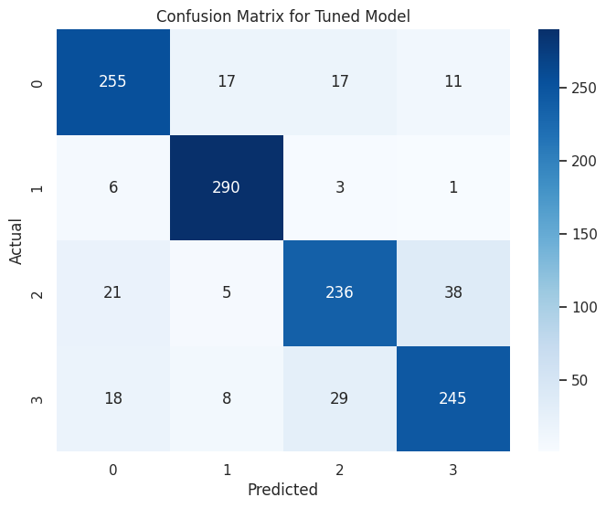

```python
# Step 8: Evaluating the tuned Random Forest model on the test set
print("Evaluating the tuned model's performance on the test set...")
y_pred_tuned = grid_search.predict(X_test)

# Printing performance metrics for the tuned model
print("Tuned Model Classification Report:")
print(classification_report(y_test, y_pred_tuned))
print("Tuned Model Accuracy:", accuracy_score(y_test, y_pred_tuned))

# Display confusion matrix for the tuned model
print("Displaying confusion matrix for the tuned model:")
import matplotlib.pyplot as plt
import seaborn as sns

conf_matrix = confusion_matrix(y_test, y_pred_tuned)
plt.figure(figsize=(8,6))
sns.heatmap(conf_matrix, annot=True, fmt='d', xticklabels=np.unique(y), yticklabels=np.unique(y), cmap="Blues")
plt.title("Confusion Matrix for Tuned Model")
plt.xlabel("Predicted")
plt.ylabel("Actual")
plt.show()
```

============================================================================================

**Model Building - Transformer**